# Session 7: Distributions and simulation

In this session we will explore the use of R to work with and visualize distributions. We will also learn about how to use simulations to better understand statistics.

First let’s load the necessary libraries.

```r
library(ggplot2)
library(dplyr)
library(tidyr)
library(NHANES)
library(gridExtra)
require(mosaic)
```

#### Visualizing an empirical distribution

We will start by working with the NHANES data. Let’s grab the height data for adults, and plot a histogram. (We worked with these data before, in Lecture 5.)

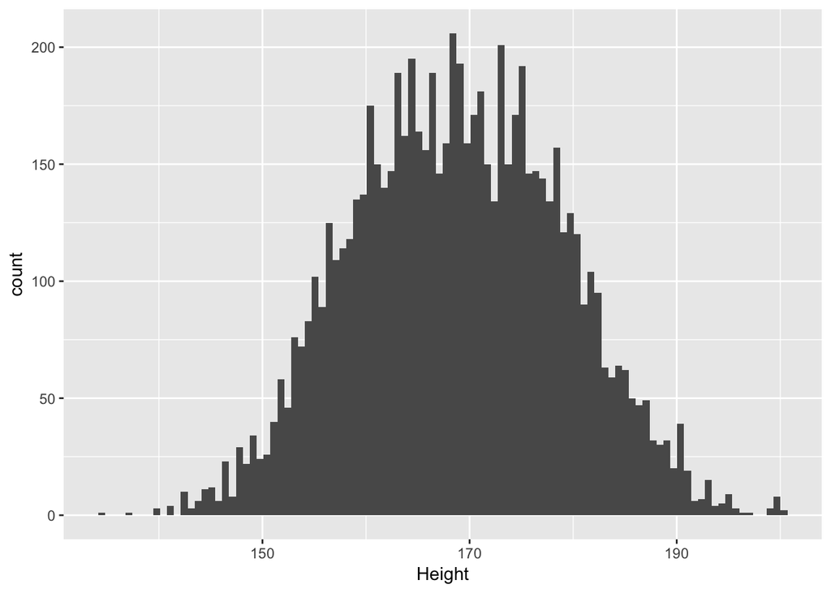

```r
NHANES$isChild <- NHANES$Age<18
NHANES_adult=subset(NHANES,subset=!isChild & Height!='NA')

ggplot(data=NHANES_adult,aes(Height)) +
  geom_histogram(bins=100)
```

We can also visualize this as a cumulative distribution.

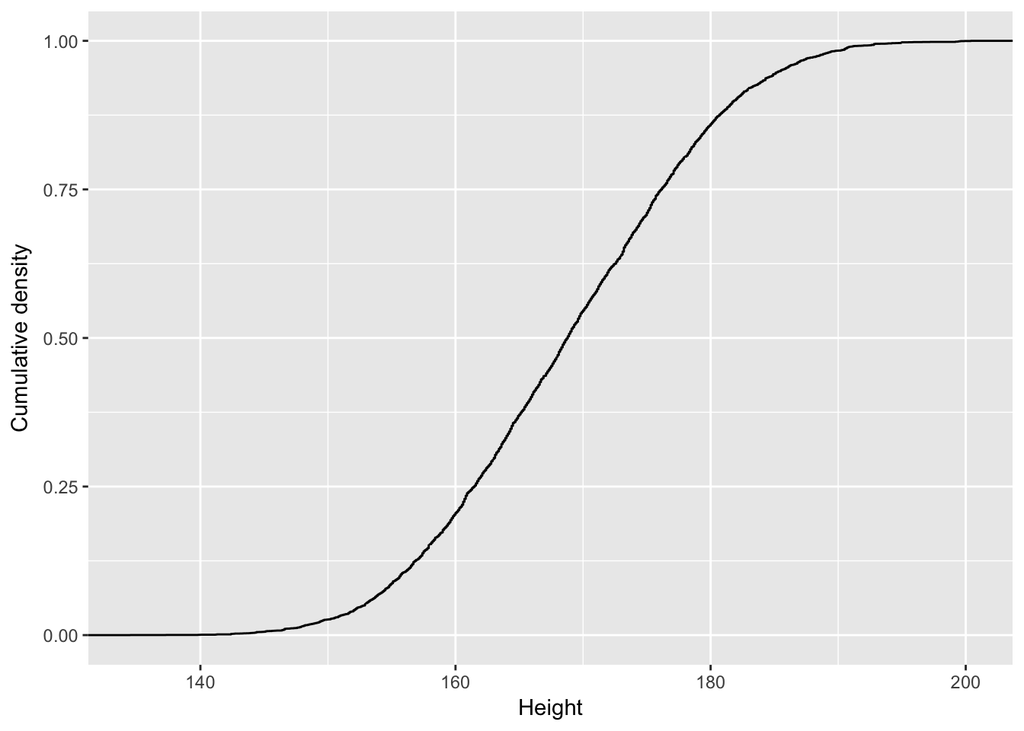

```r
ggplot(NHANES_adult, aes(Height)) +
  stat_ecdf() +
  ylab('Cumulative density')
```

Now let’s pick one person at random from the crowd.

```r
s=sample_n(NHANES_adult,1)
print(paste('Height of sampled person:',s$Height,'inches'))
```

```
## [1] "Height of sampled person: 152.1 inches"
```

We would like to see where this person falls in the distribution of all adults. Let’s start by visualizing this on the histogram by placing a line on the histogram to mark where the individual falls.

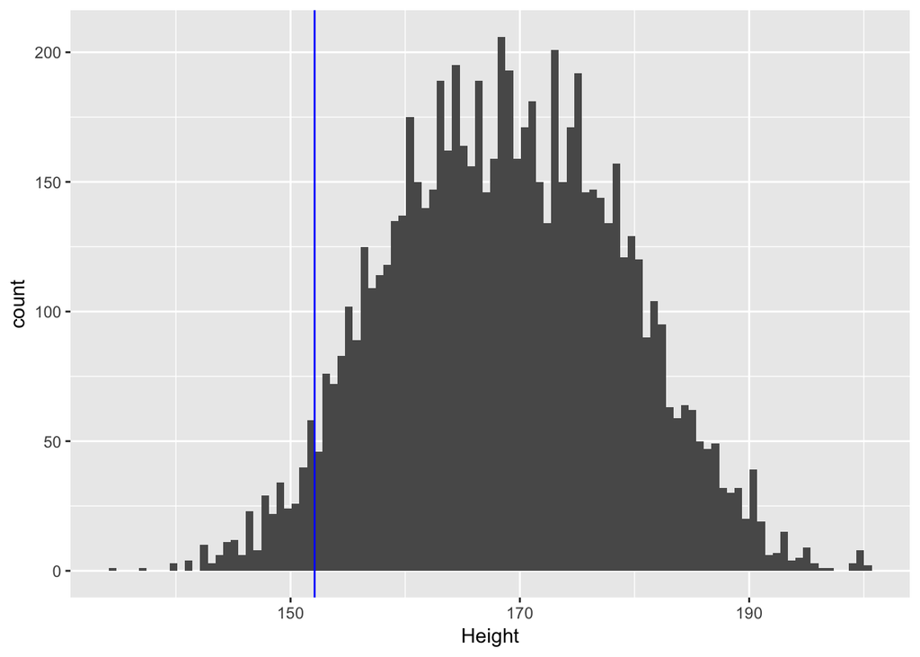

```r
ggplot(data=NHANES_adult,aes(Height)) +
  geom_histogram(bins=100) +
  geom_vline(xintercept=s$Height,color='blue')
```

Question: Would this person have a positive or negative Z-score? How do you know?

Let’s compute the Z-score to see.

```r
zHeight=(s$Height - mean(NHANES_adult$Height))/sd(NHANES_adult$Height)
print(paste('Zscore:',zHeight))
```

```
## [1] "Zscore: -1.65874057844911"
```

Now let’s see what percentile this person falls at in the distribution of all adults in the dataset.

```r
pctile=mean(NHANES_adult$Height<s$Height)*100
print(paste('Percentile:',pctile))
```

```
## [1] "Percentile: 4.17564655172414"
```

Let’s visualize this in terms of the cumulative distribution.

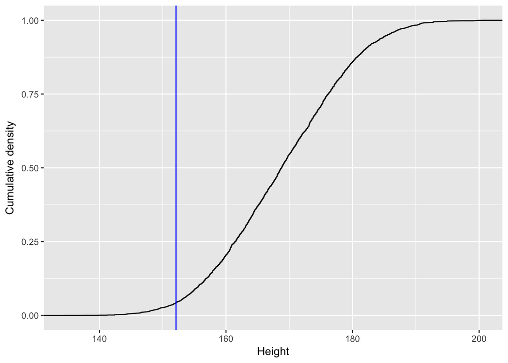

```r
ggplot(NHANES_adult, aes(Height)) +
  stat_ecdf() +
  ylab('Cumulative density') +
  geom_vline(xintercept = s$Height,color='blue')
```

### Theoretical distributions

We often use theoretical distributions to describe data, and they are also essential for creating random numbers that we will use in our simulations.

We will discuss three very important theoretical distributions.

#### Normal distribution

We have already discussed the normal distribution, which is very common in real-world data whenever our measurements are generated by many different factors.

Within R, there are several functions to work with normal distributions. First, we can use dnorm() to obtain the density under the curve for any value. Let’s plot it for a range of values.

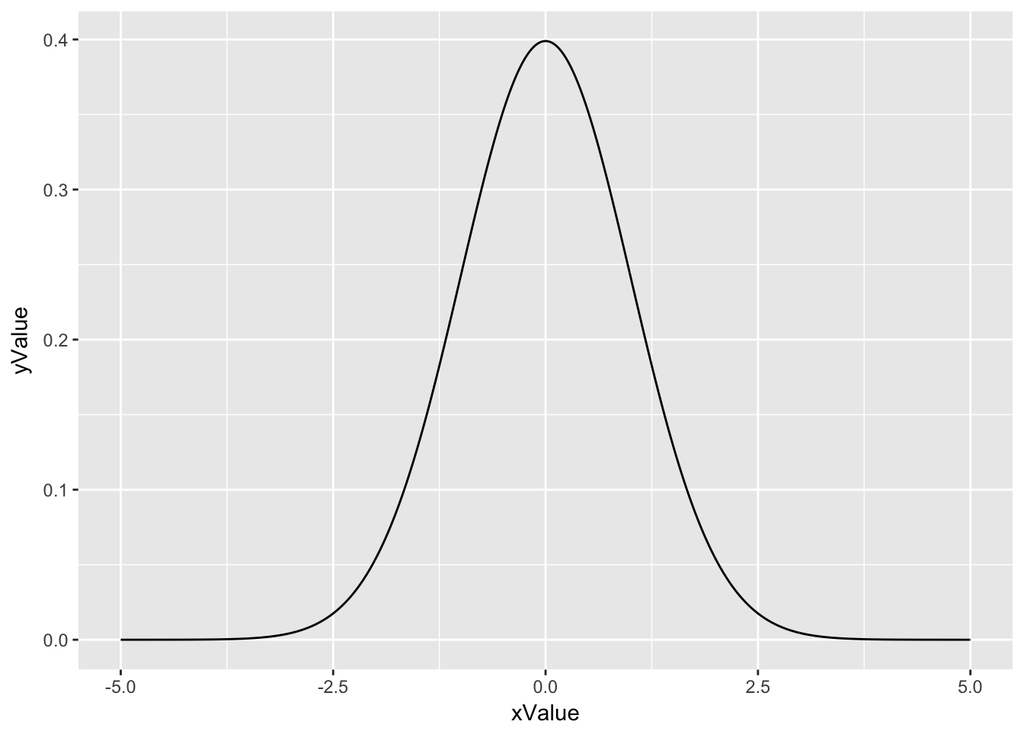

```r
xValue=seq(-5,5,0.01)
yValue=dnorm(xValue,mean=0,sd=1)
dfNormal=data.frame(xValue,yValue)
ggplot(dfNormal,aes(xValue,yValue))+
  geom_line()
```

What value of X do you think has the highest density?

```r
maxDensity=max(dfNormal$yValue)
maxValue=dfNormal$xValue[dfNormal$yValue==maxDensity]
print(paste('maximum density at',maxValue))
```

```
## [1] "maximum density at 0"
```

We can also plot the cumulative distribution function for the normal.

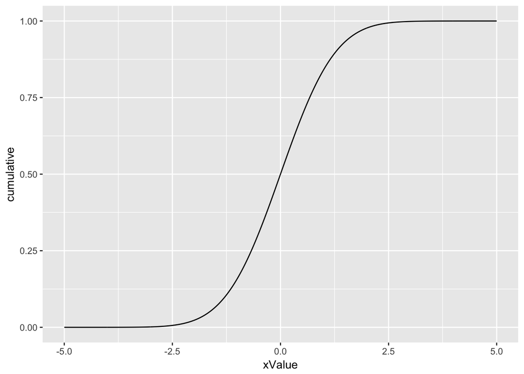

```r
dfNormal$cumulative=pnorm(dfNormal$xValue)
ggplot(dfNormal,aes(xValue,cumulative))+
  geom_line()
```

Remember that Z-scoring a set of values should move their distribution to match a standard normal distribution (with a mean=0 and sd=1). Let’s plot the Z-scored NHANES height data next to the cumulative normal distribution.

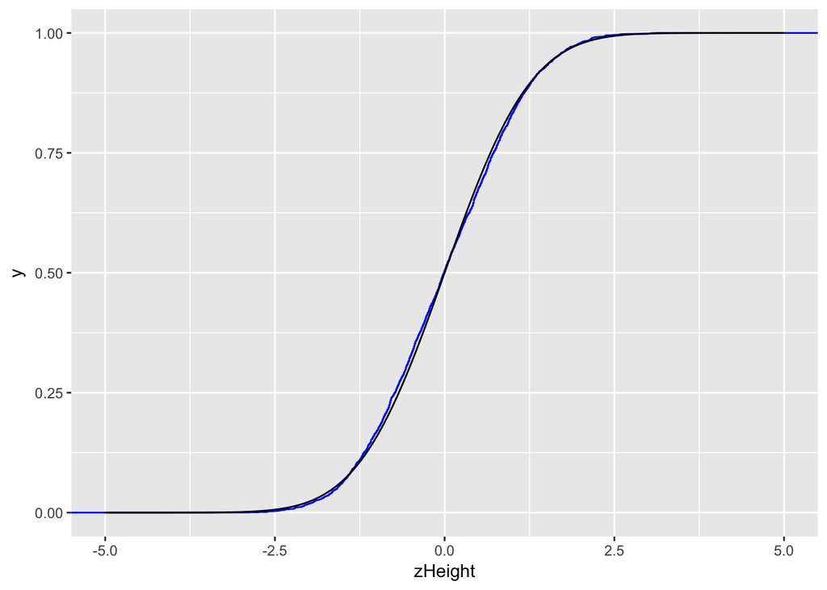

```r
NHANES_adult$zHeight=(NHANES_adult$Height - mean(NHANES_adult$Height))/sd(NHANES_adult$Height)

ggplot(NHANES_adult,aes(zHeight)) +
  stat_ecdf(color='blue') +
  geom_line(data=dfNormal,aes(xValue,cumulative))
```

You can see that the data match the normal distribution almost exactly. What if we look at data that we know are not normally distributed? Let’s take the full distribution of heights in NHANES (including children) as an example.

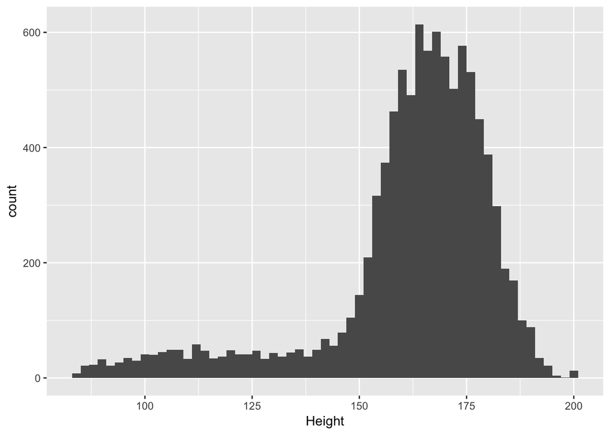

```r
ggplot(NHANES,aes(Height))+
  geom_histogram(binwidth=2)
```

We can compare this to the normal distribution by plotting the cumulative distribution functions next to one another.

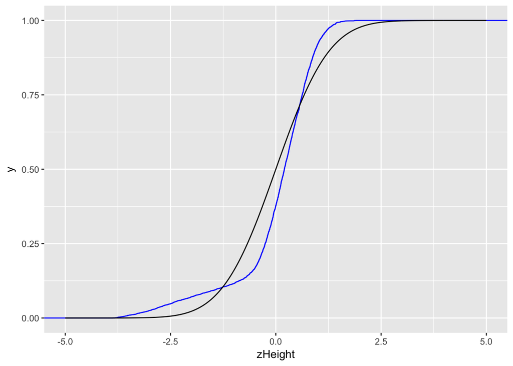

```r
NHANES$zHeight=(NHANES$Height - mean(NHANES$Height,na.rm=TRUE))/sd(NHANES$Height,na.rm=TRUE)
ggplot(NHANES,aes(zHeight)) +
  stat_ecdf(color='blue',na.rm=TRUE) +
  geom_line(data=dfNormal,aes(xValue,cumulative))
```

Here you see that the cumulative distribution does not have the classic sigmoid shape of the normal. Another way to view this is to plot the observed values directly against those expected from the theoretical distribution - if they are the same then we expect the values to fall along the diagonal of the plot. This is known as a “quantile-quantile” or “Q-Q”" plot.

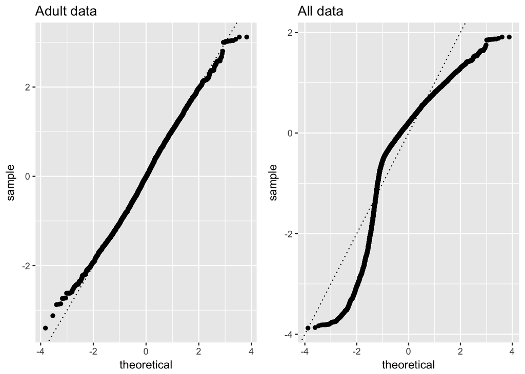

```r
p1 <- ggplot(NHANES_adult,aes(sample=zHeight)) +
  geom_qq(na.rm=TRUE) +
  ggtitle('Adult data') +
  geom_abline(intercept = 0, slope = 1,linetype='dotted')

p2 <- ggplot(NHANES,aes(sample=zHeight)) +
  geom_qq(na.rm=TRUE) +
  ggtitle('All data')+
  geom_abline(intercept = 0, slope = 1,linetype='dotted')

grid.arrange(p1, p2, ncol = 2)
```

#### Binomial distribution

The binomial distribution describes the probability distribution over a number of independent events. For example, if we flip a coin ten times, then the distribution of each particular number of heads would be described by a binomial distribution.

*Exercise*: Flip a coin ten times and record the number of heads. If you don’t have a coin, search for “google coin flip” and run it ten times instead.

Then go here and enter your count: https://goo.gl/forms/JsYggzxgYIriLDPU2

Let’s plot the data as a bar graph, and the theoretical expectation from the binomial distribution using points.

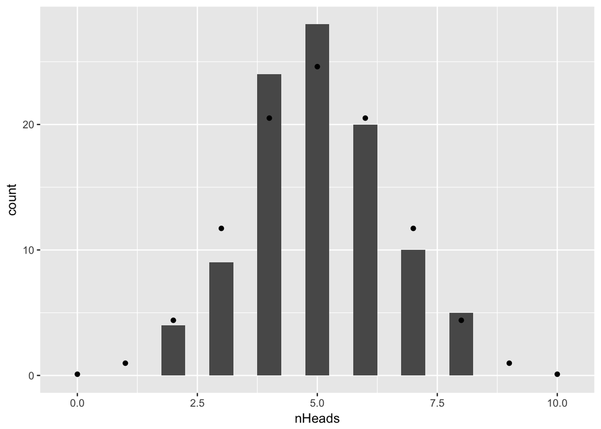

```r
coinFlipData=read.table("Coin flip.csv",sep=',',header=TRUE)
names(coinFlipData)=c('timestamp','nHeads')
nHeads=rbinom(100,10,0.5)
coinFlipData=data.frame(nHeads)

binomDist=data.frame(nHeads=seq(0,10),prob=dbinom(seq(0,10),10,0.5)*dim(coinFlipData)[1])

ggplot(coinFlipData,aes(nHeads)) +
  geom_histogram(binwidth=0.5) +
  geom_point(data=binomDist,aes(nHeads,prob))
```

#### Uniform distribution

Another very useful distribution that we will work with is the “uniform” distribution, in which all values between the minimum and maximum value are equally likely. We will generally work with a version that has a minimum of zero and a maximum of one. It’s not very common to find uniformly distributed data in the real world, but the uniform distribution can be very useful for simulations, as we will discuss below.

Questions:

1. Can you think of examples of data in the real world that might be uniformly distributed?
2. What do you think the cumulative distribution function for the uniform distribution looks like?

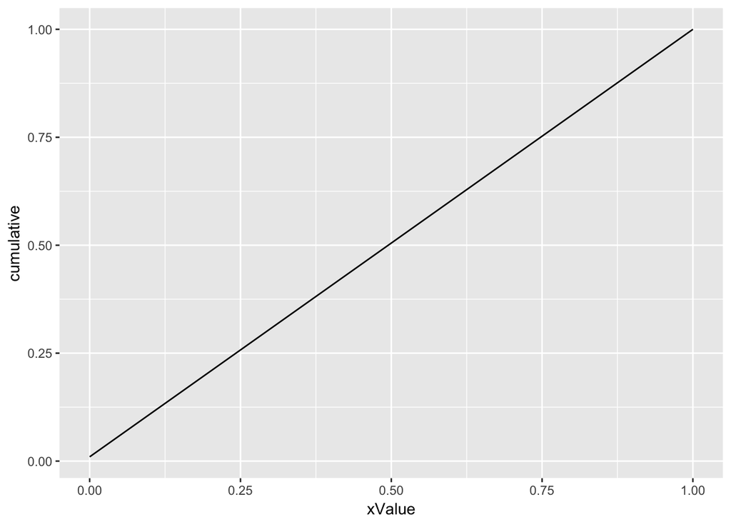

```r
xValue=seq(0,1.,0.01)
yValue=dunif(xValue)
dfUniform=data.frame(xValue,yValue)
dfUniform$cumulative=cumsum(dfUniform$yValue)/dim(dfUniform)[1]
ggplot(dfUniform,aes(xValue,cumulative))+
  geom_line()
```

### Creating random numbers

Question: What does “random” mean to you?

### Simulation

Let’s start by simulating something very simple: a coin flip.

```r
sample=runif(1)
if (sample<0.5) {
  outcome='H'
} else {
  outcome='T'
}
print(paste(sample,outcome))
```

```
## [1] "0.437407724559307 H"
```

Let’s do this many times and see how it turns out.

```r
coinflip = function() {
  sample=runif(1)
  if (sample<0.5) {
    outcome='H'
  } else {
    outcome='T'
  }

  return(c(outcome))
}

flips=do(100) * coinflip()
```